# Data Visualization, Modeling, and R Programming

# Visualizing Data: scatter plot

Scatterplots are crated with the **geom_point()** geom. If you have an issue with overplotting points, you can add a small about of randomness to each point’s position with **geom_jitter()**.

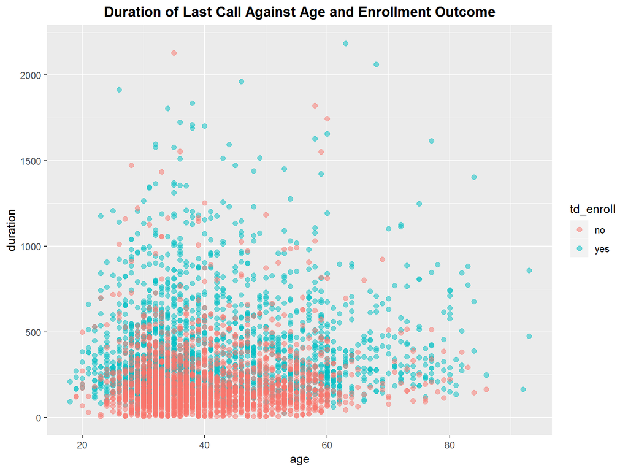

```r
banksmp %>%
    ggplot(aes(x = age, y = duration, color = td_enroll)) +
    geom_point(size = 2, alpha = 0.5) +
    ggtitle("Duration of Last Call Against Age and Enrollment Outcome") +
    theme(plot.title = element_text(face = "bold", hjust = 0.5))
```

# Try it!: scatter plot

Which of these code chunks would result in the plot below?

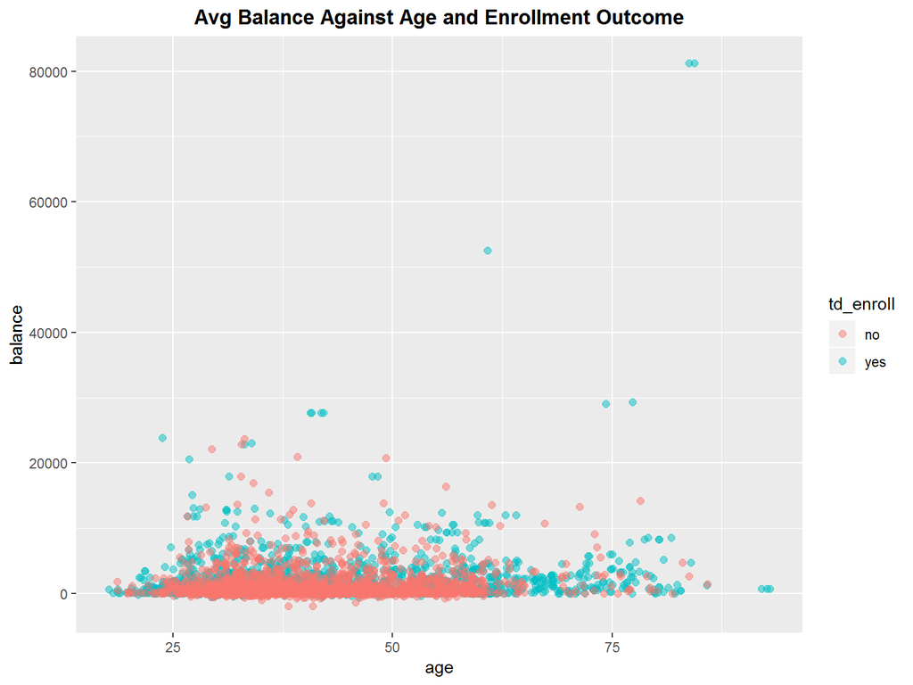

# Try it!: scatter plot (MC)

```r
### Option A
banksmp %>%
    ggplot(aes(x = age, y = balance, color = td_enroll)) +
    geom_point(size = 2, alpha = 0.5) +
    ggtitle("Avg Balance Against Age and Enrollment Outcome")

### Option B
banksmp %>%
    ggplot(aes(x = age, y = balance, color = td_enroll)) +
    geom_jitter(size = 2, alpha = 0.5) +
    ggtitle("Avg Balance Against Age and Enrollment Outcome") +
    theme(plot.title = element_text(face = "bold", hjust = 0.5))

### Option C
banksmp %>%
    ggplot(aes(x = balance, y = age, color = td_enroll)) +
    geom_point(size = 2, alpha = 0.5) +
    ggtitle("Avg Balance Against Age and Enrollment Outcome") +
    theme(plot.title = element_text(face = "bold", hjust = 0.5))
```

# Visualizing Data: pie chart

To build a pie chart, you’ll want to use **polar coordinates**:

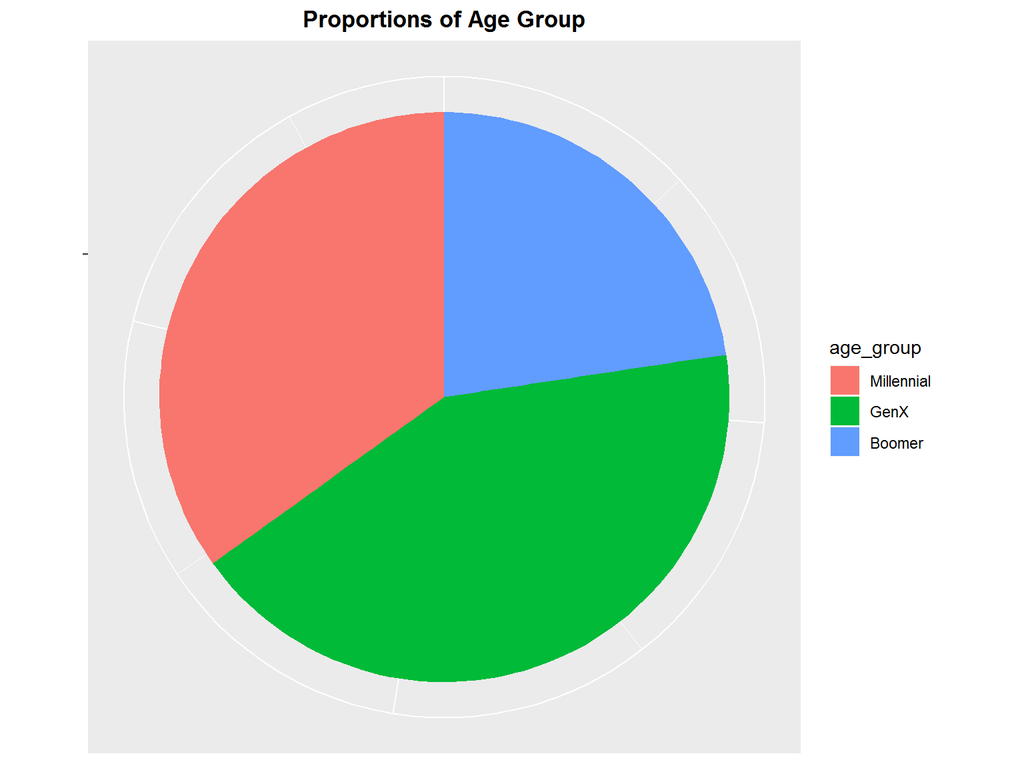

```r
banksmp %>%
    ggplot(aes(x = factor(1), fill = age_group)) +
    geom_bar(width = 1) +
    coord_polar(theta = "y") +
    ggtitle("Proportions of Age Group") +
    theme(axis.text.y = element_blank(), axis.text.x = element_blank(), axis.title.y = element_blank(),
          axis.title.x = element_blank(), plot.title = element_text(face = "bold", hjust = 0.5))
```

# Introduction to caret

The convenience of the **caret** package is its ability to call many modeling/ML packages and their algorithms without having to manually load each one; as well as functions convenient for subsetting and pre-processing data. Take time to read the [caret documentation](http://topepo.github.io/caret/index.html) for more information.

- **CreateDataPartition()**: create subsets of your data for training and testing a model
- **train()**: train a model fit. Contains a *method* argument for specifying the type of model, followed by any model parameters
- **predict()**: predict a model fit on new data
- **set.seed()**: helps with reproducible research by generating a sequence of pseudo random numbers for use in an algorithm which uses randomization (e.g. optimization)
- **confusionMatrix()**: create confusion matrix (tp, fp, tn, fn) to evaluate a classification algorithm

This package follows the *formula notation* common in R:

```r
# the ~ represents that we are modeling the Dependent Variable (DV) upon a list of Independenvt Variables (IV) based upon a list of IVs separted by +
DV ~ IV1 + IV2 + IV3 + ... + IVn

# if you'd like to model a DV based upon all IVs, put a . after the ~
DV ~ .
```

# Creating Train and Test Subsets

The **caret** package makes it easy to create subsets of your data for training and testing models. First, we can use the **createDataPartition()** function to return a list of indices for a training set, then use these indices to actually split our data.

```r
# randomly sample 70% of data without replacement and return their index position
indxtrain <- createDataPartition(y = banksmp$td_enroll, p = 0.7, list = FALSE)

# use the index positions to create a subset for training the models
banktrain <- banksmp[indxtrain,]

# back out those records in the training set to create a subset for testin the models
banktest <- banksmp[-indxtrain,]

# keep that environment clean!
rm(i, indxtrain)
```

# Building and Evaluating a Logistic Regression Model

Here we will build a logistic model with *td_enroll* as the dependent variable, and *age*, *duration*, *balance*, and *previous* as independent variables.

```r
# fit a logistic regression model with DV = td_enroll and IVs = age, duration, balance, previous
logfit <- train(td_enroll ~ age + duration + balance + previous,
                data = banktrain , method = "glm", family = "binomial")

# predict outcome in test data set using logfit
logclasses <- predict(logfit, newdata = banktest)

# view confusion matrix for prediction accuracy and other metrics
confusionMatrix(data = logclasses, reference = banktest$td_enroll, positive = "yes")
```

[output not shown]

This model could definitely be improved upon with some analytical tender, love, and care. But now you have an idea of how to fit a model using the **caret** package.

# Building and Evaluating a Decision Tree Model

```r
# fit a CART decision tree with all IVs explaining the DV
dtfit <- train(td_enroll ~ ., data = banktrain, method = "rpart")

# predict outcome in test data set using dtfit
dtclasses <- predict(dtfit, newdata = banktest)

# view confusion matrix for prediction accuracy and other metrics
confusionMatrix(data = dtclasses, reference = banktest$td_enroll, positive = "yes")

# using the rpart.plot pacakge we can view the model structure
rpart.plot(dtfit$finalModel)
```

[output not shown]

**Note** if you’re using a parametric model, then the tuning parameters will be supplied to arguments after *method*.

# R Control Flow

Many R users find that they can get by perfectly with stepping through code chunks iteratively (similar to what we’ve been doing during these trainings). However, R would not be a *programming language* without a formal **control flow**, or constructs useful in building functions, programs, and packages. Examples of three common control flows constructs are shown below, see **?Control** for more information.

```r
# example of the for loop syntax.This will iterate through the elements of an obect, performing the operations inside the loop for each iteration
for (i in seq_along(x)) {
    # do something here

    # then do some more here
}

# example of a while loop.This will iterate through the elements of an object while the condition
# still holds true. Make sure there eventually is a break from the loop, else you'll get caught in an infinite loop
while (condition) {
        # do something here

    # then do some more here
}

## example of if-elseif-else flow
if (condition1) {
    # do this
} else if (condition2) {
    # else do this
} else {
    # if the first two conditions aren't true, then do this!
}
```

# The *apply Function Family

An alternative to using for loops in R is available with the ***apply** family of functions.

The family includes **apply()**, **lapply()**, **vapply()**, **sapply()**, and more! Amongst them all, the premise remains the same: apply a function to each element of an object. The differences lie in which object types are supplied to the function as well as the type of object(s) returned as a result.

```r
# apply the table() function to the second through fifth cols of banksmp and return results as a list
lapply(banksmp[c(2:5)], table)
```

For more information on this family of functions see [DataCamp’s tutorial](https://www.datacamp.com/community/tutorials/r-tutorial-apply-family#gs.BLHZWbs).

# Writing Your Own Functions

Functions are another type of object in R. You can define your own functions for use in analysis using the **function(x)** command as such:

```r
myfunc <- function(x) {
    # something here

    # something else here
}
```

In the example above, **x** represents an argument to the **myfunc** function. You can specify more arguments, and assign any argument a default value using **arg = [somthing here]**.

# Try it!: Defining a Function to Calculate Factorials

```r
# here is one way to right a function to return the nth factorial
# it works, but could be improved for efficiency since it can only take one number
# and doesn't "learn" from previous calls (i.e. has to recompute each time)
factorial <- function(x) {
    if (x < 0) {
        stop("x should be greater than or equal to zero")
    } else if (!(x %% 1 == 0)) {
        stop("x should be an integer value")
    }

    sqce <- seq_len(x)
    tot <- 1

    if (x == 0) {
        return(tot)
        } else {

        for (i in sqce) {
            tot <- tot * i
        }
    }
    print(tot)
}

# what shold the factorial of 6 return?
factorial(6)
```

# Additional Materials

- *ggplot2* by Hadley Wickham
- *R Inferno* by Patrick Burns
- Continue working through remaining **swirl** interactive exercises
- Start exploring **R-bloggers**, **Stack Overflow**, **Quick-R**, and anything else you can get your hands on!

# Week in Review / Q&A

ALOT of information was covered this week. With what you’ve learned, you’re now prepared to perform analysis in R from start to finish. Furthermore, by taking time to digest and review the materials presented, you can start to make connections amongst the concepts and continue developing your skillset.

- R Data Structures, Operators, Common *base* Functions
  - While it’s important to understand R’s data structures, you also saw this week that the **data frame** is the most common data structure you’ll encounter during analysis
- Reading and Writing Data
- Reshaping and Manipulating Data, Parsing Strings
  - This is where the **tidyverse** really shows its advantages. If you ever want to undertake a challenging exercise, try to reproduce some of the results from day two using only *base* and *utils* functions
- Graphing and Building Models
- Programming in R with functions and control flow

**Thank you for attending, I hope you found it useful and educational. As you continue to explore R, I encourage you to share things you find helplful and/or interesting- don’t forget that *open source* is all about collaboration and shared learning. Now…let’s open it up for some questions!**